# Electronic Laboratory Notebook

ordinal

## Analysis 2/1: Basic Statistics

Back to the experiment page

## Basic Statistics:

These very roughly characterize what kind of data structure we get out of simulation.

```
##
## NUMBER OF VERTIXES:
## penaltyHolder=299148
## situationInst=497117
## benefitHolder=297117
## situation=200000
## agent=10000
## god=1
##
## NUMBER OF EDGES:
## knowsLinks=25524
## challenged=299669
## interpreted=299148
## buffered=300216
## processed=297117
## reinterpreted=297117
## forgot=386
##
## PERFORMANCE:
## Number of atomic events: 1493653
## Total simulation time (secs): 24434.1941466160
## Total simulation time (hours): 6.7872761518
## Average time per atomic event (secs): 0.0163586818
```

## Average benefit change:

```
##
## AVERAGE TOTAL BENEFIT:
## 58.54245547979997
```

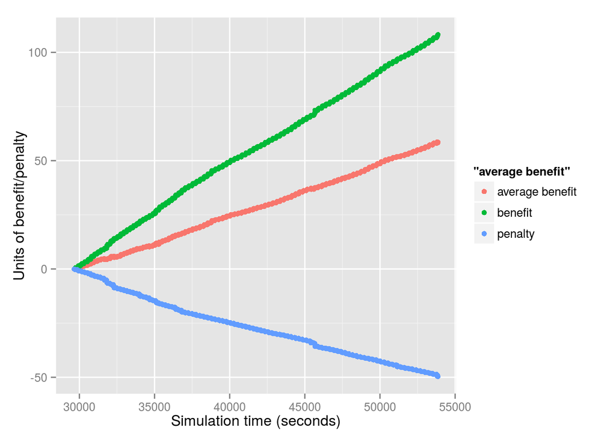

## Discussion

The graph with average benefit change does not seem very interesting - the benefit just increases and looks quite different from the one produced by Evo in chalprop-matlab simulation with the same parameters (see [presentation](http://ecco.vub.ac.be/sites/all/files/seminarMATLABGB.pdf), page 9). Also, the average degree and number of knowsLinks in the graph is somewhat suspicious: 2.5 is way too little for what you would expect from 200,000 situations and 100 iterations. There are two possibilities as always - some sort of bug preventing the simulation run correctly or… feature of the algorithm.

Anyway, more checking needed. I’d say:

- first of all check the distribution of situation to the agents (is it random);
- degree distributions and weight distributions…

ordinal

## Experiment 2: 10k Agents / 100 Generations

# Experimental setup:

I am repeating Evo’s original experiment with [chalprop-matlab](https://bitbucket.org/evob/chalprop_matlab) and presented in GBI seminar which is available [here](http://ecco.vub.ac.be/?q=node/209). The main goal of performing experiments with challprop-java is to observe the self-organization of the network defined in [this paper](http://pespmc1.vub.ac.be/Papers/ChallengePropagation.pdf) and test hypotheses formulated there.

Experiment version (challprop-experiments): fecb9bd  
Simulation version of experiment ([challprop-java](https://bitbucket.org/gbi/challprop)): 0f1bdd2  
(use `git checkout $commit$` if needed)

# Analysis:

Quite a few things can be checked on the data generated by the simulation. I perform a related analysis for each of them and report results in separate blog posts:

Analysis #2/1: benefit increase (does not look good…)

Analysis #2/2: dynamics of link weights (comming later…)

Analysis #2/3: relaxation (comming even later…)

# Full list of simulation’s parameters:

This is a long list mainly for the reference..

```
## $graphDatabase
## [1] "TitanCassandraLocal"
##
## $gephiVisualization
## [1] "false"
##
## $useDatabaseOfVectors
## [1] "true"
##
## $useDatabaseOfMatrixes
## [1] "true"
##
## $rivalComponents
## [1] "[0, 1, 2, 3, 4]"
##
## $cstSituation
## [1] "0.05"
##
## $densityVectorSituation
## [1] "0.25"
##
## $percnegSituation
## [1] "0.2"
##
## $exponentSituation
## [1] "2"
##
## $numberOfAgents
## [1] "10000"
##
## $decayFactor
## [1] "1"
##
## $decayRate
## [1] "0.03"
##
## $reciprocityRate
## [1] "0.2"
##
## $weightImportance
```

[output cut: 67 more lines]

```
##
## $simulationFinishCPU
## [1] "13135435550944"
##
## $archivingFinishedWall
## [1] "54718185250031"
##
## $archivingFinishedCPU
## [1] "13414696410662"
##
## $deletingCassandraWall
## [1] "54718201348112"
##
## $deletingCassandraCPU
## [1] "13414709258233"
```

ordinal

## Benchmarking Challprop-java vs. Chalprop-matlab

Date: Fri Dec 5 20:15:43 2014  
Analysis version (challprop-analytics): fd7ed1b  
(use `git checkout $commit$` if needed)

## Setup

The benchmarking of [chalprop-matlab](https://bitbucket.org/evob/chalprop_matlab) vs [challprop-java](https://bitbucket.org/gbi/challprop/wiki/Home) was performed by running simulations with identical parameters (to the extent different implementations allowed it) and logging running times. I was logging only [CPU time](http://en.wikipedia.org/wiki/CPU_time) and [Wall time](http://en.wikipedia.org/wiki/Wall-clock_time) - I probably had to log memory usage too, because that made quite a difference…

The hardware used:

```
system              SZ68R2 (1.0)
memory(RAM)         16GiB System Memory
processor           Intel(R) Core(TM) i7-2600 CPU @ 3.40GHz
configuration:      cores=4 enabledcores=4 threads=8
disk                2TB ST2000DM001-9YN1
in short:           kinda super-duper (more-or-less)
```

Main stable parameters across all the simulations:

```
number of generations:              100;
new situations/generation:          20% of number of agents;
components in vector:               10;
no of rival components              50%;
negative components in situations:  20%;
```

Statistics of times spent on simulations in total and per one agent is presented in tables and graphs in Results then followed by some Discussion.

## Results

### Total simulation time:

time values are in seconds

| number of agents | wall time - matlab | cpu time - matlab | wall time - java | cpu time - java |
| --- | --- | --- | --- | --- |
| 10 | 365 | 1.00 | 17.86 | 12.47 |
| 20 | 368 | 3.00 | 24.54 | 17.67 |
| 30 | 372 | 4.00 | 29.63 | 21.91 |
| 40 | 380 | 8.00 | 37.39 | 27.19 |
| 50 | 392 | 12.00 | 44.08 | 32.04 |
| 60 | 408 | 16.00 | 44.10 | 31.64 |
| 70 | 430 | 21.00 | 47.44 | 34.34 |
| 80 | 455 | 25.00 | 58.46 | 42.77 |
| 90 | 487 | 31.00 | 63.02 | 46.17 |
| 100 | 519 | 31.00 | 65.01 | 46.70 |
| 200 | 630 | 111.00 | 111.57 | 79.83 |
| 400 | 888 | 258.00 | 227.30 | 162.67 |
| 600 | 1255 | 366.00 | 358.65 | 248.83 |
| 800 | 1672 | 415.00 | 486.30 | 333.75 |
| 1000 | 1972 | 296.00 | 633.72 | 427.45 |
| 2000 | 1582 | 1588.00 | 1362.68 | 940.40 |
| 3000 | 12966 | 12893.00 | 2473.10 | 1691.49 |
| 4000 | 22093 | 21951.00 | 5274.61 | 3146.74 |
| 5000 | 62620 | 62889.81 | 7675.02 | 4268.96 |
| 6000 | n.a. | n.a. | 9466.64 | 5356.07 |
| 10000 | n.a. | n.a. | 24542.16 | 12931.79 |

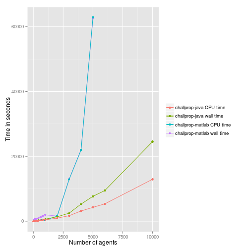

### Simulation time per agent:

time values are in seconds

| number of agents | wall time - matlab | cpu time - matlab | wall time - java | cpu time - java |
| --- | --- | --- | --- | --- |
| 10 | 36.50 | 0.10 | 1.79 | 1.25 |
| 20 | 18.40 | 0.15 | 1.23 | 0.88 |
| 30 | 12.40 | 0.13 | 0.99 | 0.73 |
| 40 | 9.50 | 0.20 | 0.93 | 0.68 |
| 50 | 7.84 | 0.24 | 0.88 | 0.64 |
| 60 | 6.80 | 0.27 | 0.74 | 0.53 |
| 70 | 6.14 | 0.30 | 0.68 | 0.49 |
| 80 | 5.69 | 0.31 | 0.73 | 0.53 |
| 90 | 5.41 | 0.34 | 0.70 | 0.51 |
| 100 | 5.19 | 0.31 | 0.65 | 0.47 |
| 200 | 3.15 | 0.56 | 0.56 | 0.40 |
| 400 | 2.22 | 0.65 | 0.57 | 0.41 |
| 600 | 2.09 | 0.61 | 0.60 | 0.41 |
| 800 | 2.09 | 0.52 | 0.61 | 0.42 |
| 1000 | 1.97 | 0.30 | 0.63 | 0.43 |
| 2000 | 0.79 | 0.79 | 0.68 | 0.47 |
| 3000 | 4.32 | 4.30 | 0.82 | 0.56 |
| 4000 | 5.52 | 5.49 | 1.32 | 0.79 |
| 5000 | 12.52 | 12.58 | 1.54 | 0.85 |
| 6000 | n.a. | n.a. | 1.58 | 0.89 |
| 10000 | n.a. | n.a. | 2.45 | 1.29 |

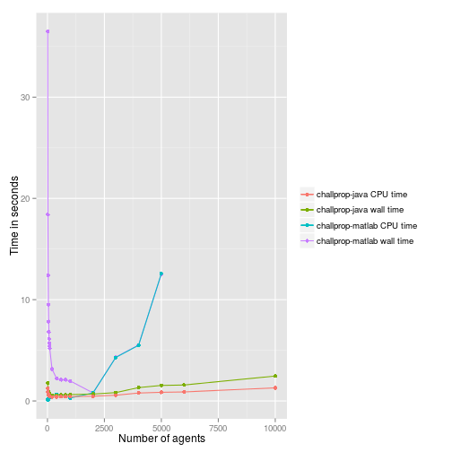

## Discussion

Challprop-java seems to be more efficient from the beginning. What is probably most important is that challprop-java time behavior is closer linear (though still with some multpilier especially at higher numbers of agents) than chalprop-matlab. As noted in the beginning I was not able to run matlab with higher numbers, so the it is not clear how it behaves when numberOfAgents > 5000.

Matlab uses one processor almost 100% of capacity all the time of simulation, therefore CPU time and wall time measures for it are almost identical. Java, on the other hand, behaves differently: CPU time is almost 2 times lower than wall time. What it probably means is that challprop-java is underutilizing CPU because it needs to wait for reads/writes from/to the graph database; this is innefficiency, althought probably contributing to using less memory. It is also an opportunity for improvement.

Final note about the overhead of using a graph database. I am actually not sure what is the exact overhead which needs some more fine-tuned benchmarking. But the reason for using graph database as underlying data structure for challprop-java was mostly motivated by the need to analyze the data coming from simulation in as great detail as possible. At my current understanding recording all the atomic events into the graph database as edges (see [challprop-java wiki](https://bitbucket.org/gbi/challprop/wiki/Home)) is the only way to meet this requirement including the fact that graph databases are specifically tuned for big data analysis. I also believe that the communication between simulation and database can be made more efficient, but this is a topic of another post.

## Code

All code for every simulation and analysis were stored in git repos listed below.

### Challprop-matlab

repo/branch:  
`git clone -b vveitas git@bitbucket.org:evob/chalprop_matlab.git`  
Version used (=commit hash):  
`git checkout 5adc760`

### Challprop-java

repo/branch:  
`git clone -b master git@bitbucket.org:gbi/challprop-experiments.git`  
Versions used (commit hash–commit message):

```
2614e57--benchmarking with 4000 agents: cputime + walltime
57133cc--benchmarking with 3000 agents: cputime + walltime
8d3377c--benchmarking with 2000 agents: cputime + walltime
a5d2385--benchmarking with 30 agents: cputime + walltime
fecb9bd--benchmarking with 10000 agents: cputime + walltime
13c4918--benchmarking with 5000 agents: cputime + walltime
3742693--benchmarking with 1000 agents: cputime + walltime
0220857--benchmarking with 800 agents: cputime + walltime
9ed6ab6--benchmarking with 600 agents: cputime + walltime
b996638--benchmarking with 400 agents: cputime + walltime
9b20c1e--benchmarking with 200 agents: cputime + walltime
15cf842--benchmarking with 100 agents: cputime + walltime
b10ebe4--benchmarking with 90 agents: cputime + walltime
8f27e55--benchmarking with 80 agents: cputime + walltime
81dc169--benchmarking with 70 agents: cputime + walltime
4aae4c2--benchmarking with 60 agents: cputime + walltime
28b6c8c--benchmarking with 50 agents: cputime + walltime
ea1c2cb--benchmarking with 40 agents: cputime + walltime
6e0899a--benchmarking with 20 agents: cputime + walltime
f4ead15--benchmarking with 10 agents: cputime + walltime
```

Simulation version of java-experiment (challprop): 0f1bdd2  
(use `git checkout $commit$` if needed)

ordinal

## Analysis 1/1

Date of analysis: Tue Nov 4 23:38:43 2014  
Analysis version (challprop-analytics): 904153b  
Experiment version (challprop-experiments: b1f16c1  
Simulation version of experiment (challprop): 9dc728f  
(use `git checkout $commit$` if needed)

## Basic Statistics:

[output not shown]

```
##
## NUMBER OF VERTIXES:
## penaltyHolder=6091
## agent=2000
## benefitHolder=6016
## situationInst=6126
## situation=110
## god=1
##
## NUMBER OF EDGES:
## knowsLinks=662
## challenged=6126
## interpreted=6091
## buffered=6081
## processed=6016
## reinterpreted=6016
## forgot=39
##
## PERFORMANCE:
## Simulation time in secs: 182
## Number of atomic events: 30369
## Time per atomic event (secs): 0.0059929533
```

## Average benefit change:

```
1
2
3
```

```
##
## AVERAGE TOTAL BENEFIT:
## 338.9991152865
```

```
1
```

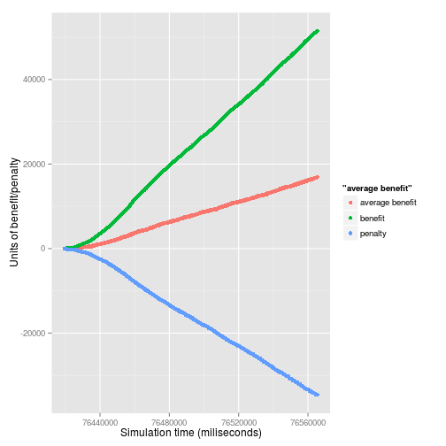

## Average benefit by category:

### Cluster C1:

```
1
2
3
```

```
##
## AVERAGE BENEFIT CLUSTER #1:
## -343.7572002800003
```

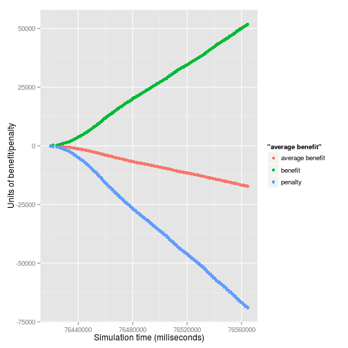

### Cluster C2:

```
1
2
3
```

```
##
## AVERAGE BENEFIT CLUSTER #2:
## 1021.7554308530008
```

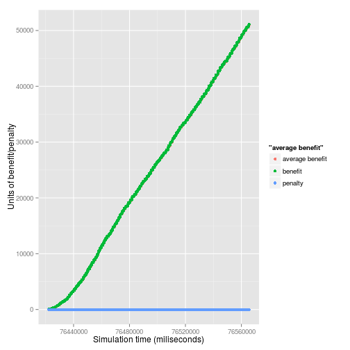

## All simulation parameters:

[output not shown]

[output cut: 37 more lines]

[output not shown]

```
## $pathOnDisk
## [1] "/media/data/gbi/eln/"
##
## $generateTestDataOnDisk
## [1] "true"
##
## $tempConfigFile
## [1] "/media/ramdisk/challprop.conf"
##
## $test
## [1] "false"
##
## $graphDatabase
## [1] "TitanCassandraLocal"
##
## $gephiVisualization
## [1] "false"
##
## $useDatabaseOfVectors
## [1] "true"
##
## $useDatabaseOfMatrixes
## [1] "true"
##
## $rivalComponents
## [1] "[0, 1]"
##
## $cst
## [1] "0.05"
##
## $densityVector
## [1] "0.5"
##
## $percneg
## [1] "0.2"
##
## $exponent
## [1] "2"
##
## $numberOfAgents
```

[output cut: 37 more lines]

```
##
## $respectKnowsLinksWeights
## [1] "false"
##
## $simulationID
## [1] "10-27-14-3:31:52PM"
##
## $simulationHome
## [1] "/media/data/gbi/eln/data/10-27-14-3:31:52PM/"
##
## $graphPath
## [1] "/media/data/gbi/eln/data/10-27-14-3:31:52PM/graph/"
##
## $experimentPath
## [1] "/media/data/gbi/eln/data/10-27-14-3:31:52PM/experiment/"
```

ordinal

## Experiment 1: Two Predefined Clusters of Agents

# Experimental setup:

The initialized network is bombarded with randomly (well, according to Evo’s algorithm) generated situations (100) and then results are analyzed. It is expected that the benefit accomulation of agents in defferent clusters will follow diferent pattern because of C1 cluster with refuse many challenges, while C2 agents will process almost everything.

# Results:

# Analysis

This experiment has only one analysis: Analysis #1/1